# Simulation of a forest of growing trees

Barbara Oliveira De Loreto

2024-04-28

# Report on simulation of a forest of growing trees

## Motivation for the model

The motivation for this simulation was a question that is relevant in the fields of carbon farming and landscape conservation: **how long would it take for a initial stand of trees to reach a target density value?** Carbon farming projects that focus on vegetation methods often have specific tree densities they need to achieve (Australian Government, Clean Energy Regulator, n.d.b) (Australian Government, Clean Energy Regulator, n.d.a). In addition, from a landscape conservation perspective, a forest with more than 20 per cent canopy covers is considered to be a woodland forest (Australian Government, Department of Agriculture and Water Resources 2018) and may have more specific managements requirements and legislative protections (Queensland Government 2014). In addition to the main question, secondary questions were:

- If the initial stand is planted in rows, does that affect the timing of reaching the desired density?
- If the initial stand is of an even age, does that affect the timing of reaching the desired density?
- Is the model reasonable in simulating at a small (1ha) and large (25ha) scale?
- Since a key management action in certain forests is weed control to support survival of young trees, does improving survival rate by 10% affect the timing of achieving the desired density significantly?

A concise literature review was carried out on key aspects of eucalyptus biology and ecology to better establish the parameters of the model. The research identified relevant studies in the field of plant growth rate, and survival rate (Ngugi et al. 2015) (Tian et al. 2020) as well as dispersal (Booth 2017).

## Description of the model

The provided individual-based model of tree growth in a forest was a great start and already included some important concepts. However, the model lacked in some elements that would make the model more realistic. In addition, for the model to be feasible given the task, some assumptions had to be made:

1. The forest is in Australia and mostly composed of eucalyptus trees (from species with similar characteristics).
2. No fire events occurred during the time period.
3. 20 per cent canopy cover is achieved with a number of trees between 150 and 200 trees per hectare.

The model was designed to take an initial forest with a certain number of trees in designated XY location and model in each time step for each tree, growth in size, aging, potential reproduction, potential death and falling of dead trees.

Below figure 1 helps understand key elements in the model:

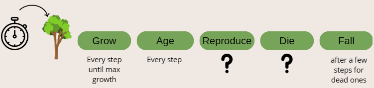

Fig 1: Diagram of the model

Each tree has the following variables associated with it:

- ID – unique identified for each tree
- Alive – condition of the tree in terms of dead or alive (if tree is alive this variable is TRUE)
- x – coordinate x for the tree location in the forest
- y – coordinate y for the tree location in the forest
- r – radius of a tree in centimetres, derived from the diameter at chest hight
- a – age of the tree. (estimate for the initial forest based on radius and mean growth rate, and then calculated in terms of time steps)
- d - number of time steps since a tree has died

The parameters used in the modelling of the forest through time are:

- maxTRees – the maximum number of trees the forest/model handles
- maxx – the maximum size of the forest in terms of x coordinate
- maxy - the maximum size of the forest in terms of y coordinate
- maxr – the maximum radius that each tree could get
- maturityr – the radius when a plant reaches maturity for reproduction
- gamma_max – top of the range for the growth rate per time step
- gamma_min – bottom of the range for growth rate per time step
- mu - mortality probability per time step for trees over 3 years
- mu_under_3 – mortality probability for plants under 3 years
- lambda - probability of producing surviving offspring after reaching maturity, per time step
- d_d – maximum dispersal distance
- min_d - minimum distance between trees
- d_f - number of time steps it takes for a dead tree to “fall”and the space be open for other trees

Key elements of this model are:

For the placement of new trees, the model attempted to place the new tree in the available space 50 times and if that was not possible, the tree was then considered dead.

The figures below illustrate this spacial element fo the model.

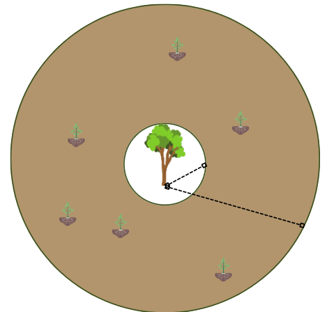

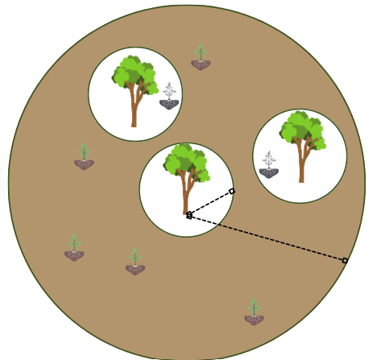

Fig 2: Dispersal element

Fig 3: Space available for new trees. New trees considered dead after 50 attempts for placement

Three different types of initial forests were used to understand the efficacy of the model and also any significant difference in the outcome given different planting approaches. The inital stands were:

- Initial stand of 10 trees randomly placed and with random age and radius.
- Initial stand of 10 trees planted in 2 rows, with even age and radius.
- Initial stand of 10 trees planted randomly in the space but with even age and radius.

In addition, one of the key parameters was modified, mortality of younger trees to understand how the model would behave.

Lastly, a test of the scalability of the model was carried out. For that, an area of 25 hectares was selected with an initial stand of 250 trees (10 per hectare).

## The code

Below is the code used for the simulation of an initial stand of 10 trees, randomly placed in 1 hectare and with randomly selected radius and age.

```r
# Simple simulation of a forest of growing trees_modification on t_steps and maximnum number of trees
# Authors: Barbara Oliveira De Loreto adapted from Jan Engelstaedter & Daniel Ortiz-Barrientos
# Date: 01/05/2021

library(animation)
library(plotrix)
library(ggplot2)
library(dplyr)
library(purrr)
library(tidyr)

# establish tmax and the initial number of trees
tmax <- 70 # number of time steps to simulate
nini <- 10  # initial number of trees

# establish the list of parameters
p <- list()
p$maxTrees <- 10^5      # number of trees (alive or dead) that the simulation can handle
p$maxx <- 100           # x-size of forest in meters (equals a hectare)
p$maxy <- 100           # y-size of forest in meter
p$maturityr <- 0.3      #size which marks the maturity for a tree - seed production
p$maxr   <- 1           # maximum radius of a tree
p$gamma_max  <- 0.1     # growth per time step max
p$gamma_min <- 0.01     #growth per step min
p$mu     <- 0.02        # mortality probability per time step
p$mu_under_3 <- 0.2     # mortality probability for plants under 3 years
p$lambda <- 0.2         # probability of producing surviving offspring after reaching maturity, per time step
p$d_d <- 30             # dispersal maximum distance
p$min_d <- 4            #minimum distance from an existing tree for new seedlings to start
p$d_f <- 3              #number of time steps it takes for a dead tree to "fall"and the space be open for other trees


# establish a dataframe with the initial forest

# initial random forest:
iniForest <- data.frame(ID    = 1:nini,                             # ID for each tree
                        alive = TRUE,                               # living or dead?
                        x     = runif(nini, min = 0, max = p$maxx), # x position
                        y     = runif(nini, min = 0, max = p$maxy), # y position
                        r     = runif(nini, min = 0, max = p$maxr), # radius
                        a     = NA,                                 # age
                        d     = NA)                                 # how long tree has been dead

# expected age based on their size using mean o gamma_mx and gamma_min
iniForest$a <- iniForest$r/((p$gamma_max + p$gamma_min)/2)
iniForest$d <- 0 # all trees are alive so no trees are dead


# core simulation function:

simulateForest <- function(iniForest, tmax, p) {
  ftt <- as.vector(rep(NA, tmax + 1), "list") # "forest through time"
  ftt[[1]] <- iniForest #copy initial forest into first space
  nextID <- max(ftt[[1]]$ID, na.rm = TRUE) + 1 #establish next ID based on the exciting ones
  for(i in 1:tmax) {
    ftt[[i + 1]] <- data.frame(ID = rep(NA, p$maxTrees), alive = NA,
                               x = NA, y = NA, r = NA, a = NA, d= 0)  # initiate the object with NAs, size is max number of trees

    # forest in new time step copied over from previous one:
    ftt[[i + 1]][1:nrow(ftt[[i]]),] <- ftt[[i]]

    # indices of living trees:
    alive <- which(ftt[[i + 1]]$alive)

    # aging all trees:
    ftt[[i + 1]]$a[alive] <- ftt[[i + 1]]$a[alive] + 1

    # growing trees:
    canGrow <- which(ftt[[i + 1]]$alive & ftt[[i + 1]]$r < p$maxr)
    ftt[[i + 1]]$r[canGrow] <- ftt[[i + 1]]$r[canGrow] + runif(1, max = p$gamma_max, min = p$gamma_min)  #growth based on a random number from a range

    # make sure they're not growing beyond maxr:
    ftt[[i + 1]]$r[ftt[[i + 1]]$r > p$maxr] <- p$maxr

    # death dynamics
    # death under 3 years
    alive_under_3 <- which(ftt[[i + 1]]$alive & ftt[[i + 1]]$a <=3)
    ftt[[i + 1]]$alive[alive_under_3] <- (runif(length(alive_under_3)) > p$mu_under_3)

    # death others:
    alive_over_3 <- which(ftt[[i + 1]]$alive & ftt[[i + 1]]$a >3)
    ftt[[i + 1]]$alive[alive_over_3] <- (runif(length(alive_over_3)) > p$mu)

    # time steps a tree has been dead
    dead <- which(!ftt[[i + 1]]$alive) #establishing an index of dead ones
    ftt[[i + 1]]$d[dead] <- ftt[[i + 1]]$d[dead] + 1

        # Updating the forest state, removing dead trees
    dead_falls <- which(ftt[[i + 1]]$d > p$d_f) #establishing an index of trees to be removed

    if (length(dead_falls) > 0) {ftt[[i + 1]] <-ftt[[i + 1]][-dead_falls,] #removing dead trees that have been there for some steps
    # re-establish the same amount of NA spaces
    add_NA <- data.frame(ID = rep(NA, length(dead_falls)), alive = NA,
                         x = NA, y = NA, r = NA, a = NA, d= 0)
    ftt[[i + 1]] <- rbind(ftt[[i + 1]], add_NA) #bind empty entries
    }

    #reestablishing alive index after trees died
    alive <- which(ftt[[i + 1]]$alive)

    # reproduction:
    for(j in alive) {
      if ((ftt[[i + 1]]$r[j]>= p$maturityr) && (runif(1) < p$lambda)){  # if r is at maturity or larger, reproduction happening?
        emptySlot <- which(is.na(ftt[[i + 1]]$ID))[1] # next empty row in dataframe
        ftt[[i + 1]]$ID[emptySlot] <- nextID
        ftt[[i + 1]]$alive[emptySlot] <- TRUE
        ftt[[i + 1]]$r[emptySlot] <- 0
        ftt[[i + 1]]$a[emptySlot] <- 0

        ## setting up check of space available
        attempt <- 0
        max_attempts <- 50 #maximum number of placement attempts

        #check if a new tree position overlaps with existing trees
        is_space_available <- function(new_x, new_y, exiting_trees, min_d) {
          min_d <- p$min_d
          existing_trees <- na.omit(ftt[[i + 1]])
          distances <- sqrt((existing_trees$x - new_x)^2 + (existing_trees$y- new_y)^2) #squared Euclidean distance between each existing tree and the proposed location
          return (all(distances>=p$min_d)) #returns true if space is available
        }

        # place a new tree, ensuring it doesn't overlap with existing trees
        existing_trees <- na.omit(ftt[[i + 1]]) #establish the existing trees with all attributes
        repeat{
          new_x <- runif(1, ftt[[i + 1]]$x[j] - p$d_d, ftt[[i + 1]]$x[j] + p$d_d) # proposed location of new plant within a certain distance from the parent plant
          new_y <- runif(1, ftt[[i + 1]]$y[j] - p$d_d, ftt[[i + 1]]$y[j] + p$d_d) # proposed location of new plant within a certain distance from the parent plant
          # checking if space is available
          if (is_space_available(new_x, new_y, existing_trees, p$min_d)) {
          ftt[[i + 1]]$x[emptySlot] <- new_x
          ftt[[i + 1]]$y[emptySlot] <- new_y
          break #break out of the repeat loop
        }
        attempt <- attempt +1
        if(attempt>=max_attempts){ #after 50 attempts, place the tree anywhere even if not available
          ftt[[i + 1]]$x[emptySlot] <- new_x
          ftt[[i + 1]]$y[emptySlot] <- new_y
          ftt[[i + 1]]$alive[emptySlot] <- FALSE
          break #after too many attempts to prevent infinite loop
       }
      }
        nextID <- nextID + 1
        emptySlot <- which(is.na(ftt[[i + 1]]$ID))[1]
      }
    }
    # get rid of empty rows:
    ftt[[i + 1]] <- ftt[[i + 1]][!is.na(ftt[[i + 1]]$ID),]
  }
  return(ftt)
}
```

For the scenarios with the planted trees in rows and the planted trees randomly in the space, the code used to establish the initial stand is below:

```r
# initial forest planted in rows
planted_forest_XY <- data.frame(x = c(rep(55, 5),rep(45, 5)),
                                y = c(40, 44, 48, 52, 56, 42, 46, 50, 54, 58))
planted_forest <- data.frame(ID    = 1:nini,                        # ID for each tree
                             alive = TRUE,                               # living or dead?
                             x     = planted_forest_XY$x,                # x position
                             y     = planted_forest_XY$y,                # y position
                             r     = 0.1,                                # radius
                             a     = 3.1,                                # age, all trees over 3yo
                             d     = 0)                                  # how long tree has been dead


# initial planted fores t random:
planted_forest_random <- data.frame(ID    = 1:nini,                             # ID for each tree
                        alive = TRUE,                               # living or dead?
                        x     = runif(nini, min = 0, max = p$maxx), # x position
                        y     = runif(nini, min = 0, max = p$maxy), # y position
                        r     = 0.1,                                # radius
                        a     = 3.1,                                # age, all trees over 3 yo
                        d     = 0)
```

The code used for the large scale simulation, only differed in the parameter related to the plot size and also the initial number of trees.

```r
tmax <- 70  # number of time steps to simulate
nini <- 250  # initial number of trees

# establish the list of parameters
p$maxx <- 500          # x-size of forest in meters (equals a hectare)
p$maxy <- 500
```

## Results

In terms of density, the random initial forest achieved density slightly earlier than the planted ones. However, to understand if this difference is significant, further studies with a relevant number of replicates would need to be designed.

Nonetheless, in all scenarios it took 50 years or more for the desired density to be achieved. That is relevant from a management perspective as over 50 years is a long time to sustain management activities but also because of some carbon farming methodologies have a designated period of only 25 years where trees have to remain uncleared for carbon credits to be generated and registered.

The graph below shows the number of tress through time for the three scenarios.

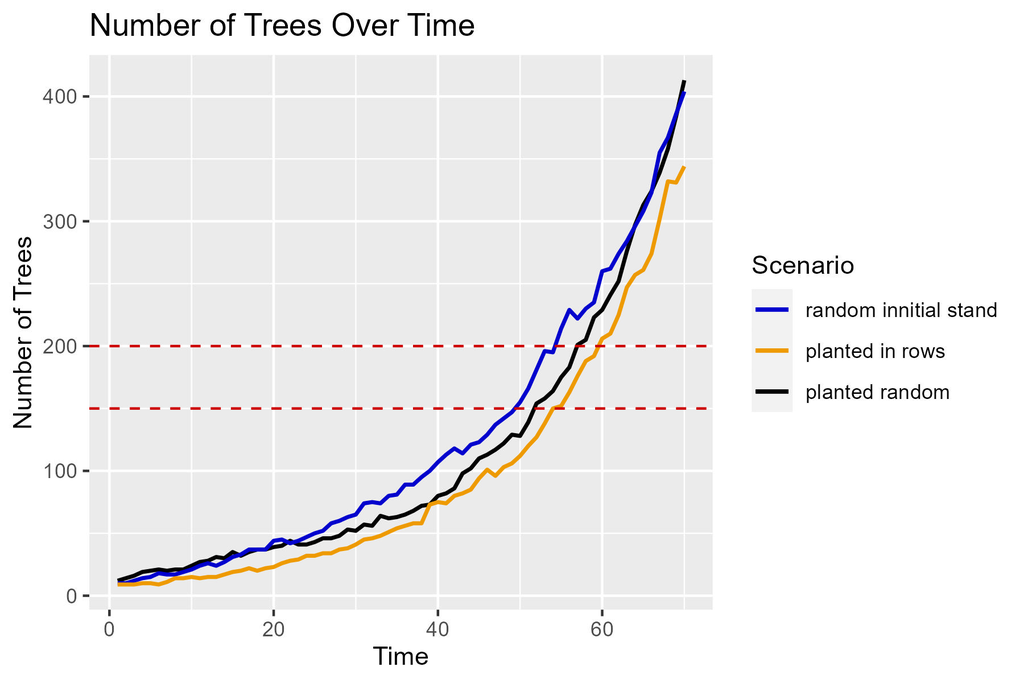

Fig 4: Density 3 scenarios

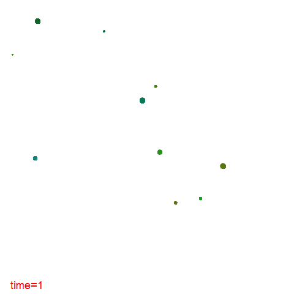

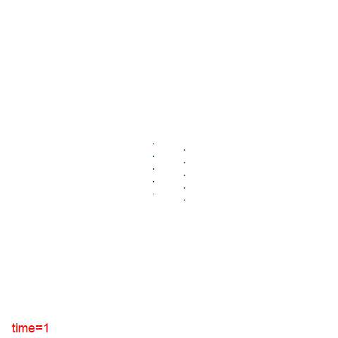

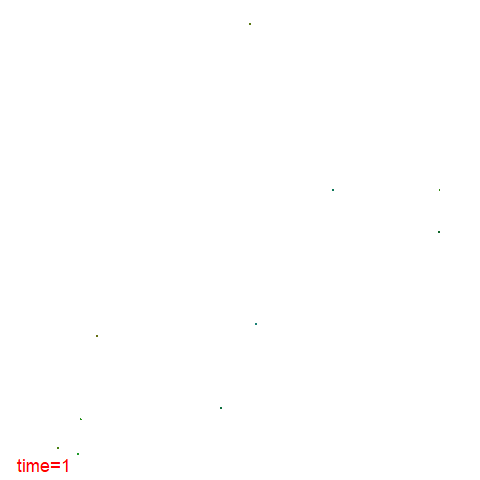

Fig 5: Dispersal random forest

Fig 6: Dispersal forest planted in rows

Fig 7: Dispersal forest planted randomly

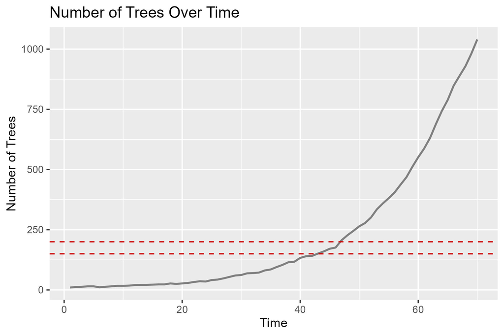

Density Improved Survival

The model also behaved similarly when using a large scale plot of 25 hectares with 10 trees per hectare.

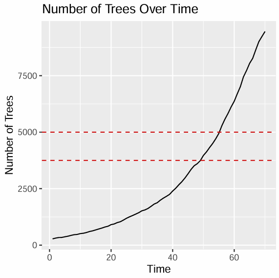

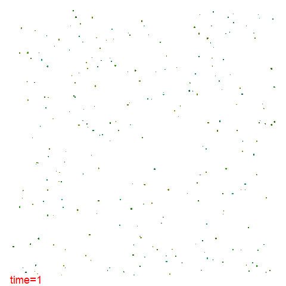

Fig 8: Number of trees overtime 25ha

Fig 9: Dispersal 25ha

## Notes

Chat GPT was used to solve some R errors that the author has never encountered before.

Data, scripts, images and background info used in this report can be found at [https://github.com/BarbaraDeLoreto/Compt_biol] (https://github.com/BarbaraDeLoreto/Compt_biol)

## References

Australian Government, Clean Energy Regulator. n.d.a. “Participating in the Emissions Reduction Fund: A Guide to the Avoided Clearing of Native Regrowth Method.” https://cer.gov.au/document/guide-reforestation-environmental-or-mallee-plantings-fullcam-method.

———. n.d.b. “Participating in the Emissions Reduction Fund: A Guide to the Reforestation by Environmental or Mallee Plantings FullCAM Method.” https://cer.gov.au/document/guide-reforestation-environmental-or-mallee-plantings-fullcam-method.

Australian Government, Department of Agriculture and Water Resources. 2018. “Australia’s State of the Forests Report 2018.” https://www.agriculture.gov.au/abares/forestsaustralia/sofr/past-reporting/sofr-2018.

Booth, Trevor H. 2017. “Goingnowherefast: A Review of Seed Dispersal in Eucalypts.” *Australian Journal of Botany* 65: 401–10. https://doi.org/10.1071/BT17019.

Ngugi, Michael R., David Doley, Mark Cant, and Daniel B. Botkin. 2015. “Growth Rates of Eucalyptus and Other Australian Native Tree Species Derived from Seven Decades of Growth Monitoring.” *J. For. Res.* 26 (4): 811–26. https://doi.org/10.1007/s11676-015-0095-z.

Queensland Government. 2014. “Eucalypt Woodlands: Regrowth Benefits - Management Guidelines 2014.” https://www.researchgate.net/profile/Paula-Peeters/publication/272493738_Eucalypt_woodlands_-_Regrowth_Benefits_Management_Guideline/links/54e67aa40cf2bff5a4f5dcc6/Eucalypt-woodlands-Regrowth-Benefits-Management-Guideline.pdf. 2014.

Tian, Xianglin, Shuaichao Sun, Blas Mola-Yudego, and Tianjian Cao. 2020. “Predicting Individual Tree Growth Using Stand-Level Simulation, Diameter Distribution, and Bayesian Calibration.” *Annals of Forest Science* 77 (1): 57. https://doi.org/10.1007/s13595-020-00970-0.